# 03 — Breakthrough curve review and hysteresis

Visual QAQC of the final tables, and event-scale hysteresis

Kauan Fonseca

2026-08-26

# Scope

This document does **no processing**: it reads the three derived tables written by `02_integration.Rmd` and renders them. If a curve looks wrong here, the fix belongs in `02`, never in `03`. It is the final visual sanity check before the tables are used for inverse modelling, and it reports the nutrient-tracer hysteresis, which is a result rather than a QAQC step.

```r
btc_conservative <- read_rds(here("data_derived", "btc_conservative.rds"))
btc_nutrients    <- read_rds(here("data_derived", "btc_nutrients.rds"))
events           <- read_rds(here("data_derived", "events.rds"))

nrow(btc_conservative); nrow(btc_nutrients); nrow(events)
```

```
## [1] 6976
```

```
## [1] 429
```

```
## [1] 14
```

# 1. The four curves per event

For every event this overlays, against time since release: the logger SpC, the logger-derived NaCl, and the two nutrients (NH4-N, SRP). SpC and NaCl are the high-resolution logger series; the nutrients are grab samples. Each panel is one event; the y-axes are free because the four quantities span different ranges.

```r
cons_long <- btc_conservative %>%
  transmute(event_id, time_min = time_since_release_s / 60,
            SpC = spc_uscm, NaCl = nacl_mgL) %>%
  pivot_longer(c(SpC, NaCl), names_to = "series", values_to = "value") %>%
  mutate(kind = "logger", variant = "background-corrected")

# Two variants of the same series: the background-corrected concentration
# (all solutes) and, for SRP only, the same value plus the House (1990)
# co-precipitation correction (Section 9.5/9.8 of `02`). Both are kept in
# the SRP facet, distinguished by colour, so the size of the correction is
# visible directly on the breakthrough curve rather than only in the
# parity plot of Section 1.1.
nut_long <- bind_rows(
  btc_nutrients %>%
    transmute(event_id, time_min = time_since_release_s / 60,
              series = solute, value = conc_corr_ugL, kind = "grab",
              variant = "background-corrected"),
  btc_nutrients %>%
    filter(solute == "SRP", !is.na(conc_corr_coprec_ugL)) %>%
    transmute(event_id, time_min = time_since_release_s / 60,
              series = solute, value = conc_corr_coprec_ugL, kind = "grab",
              variant = "+ coprecipitation")
) %>%
  filter(!is.na(value))

curves <- bind_rows(cons_long, nut_long) %>%
  mutate(series = factor(series, levels = c("SpC", "NaCl", "NH4-N", "SRP")))
```

```r
# one interactive figure per event; each variable on its own facet row so
# the different units stay readable
make_event_plot <- function(ev) {
  d        <- curves %>% filter(event_id == ev)
  d_logger <- d %>% filter(kind == "logger")
  d_grab   <- d %>% filter(kind == "grab")

  # geom_vline(xintercept = 0) is an infinite-extent geom with no data rows
  # of its own; ggplotly's conversion does not carry it across (silently
  # drops it), so it is replaced with a geom_segment anchored to each
  # facet's own y-range (scales are free_y, so a single -Inf/Inf pair would
  # not clip correctly per panel).
  vline_df <- d %>%
    group_by(series) %>%
    summarise(y_min = min(value, na.rm = TRUE),
              y_max = max(value, na.rm = TRUE), .groups = "drop")

  # background reference per panel: the pre-release/pre-addition level each
  # series is judged against. SpC's is the handheld-probe reading at release
  # (background_spc_probe, 01); NH4-N/SRP are the pre-addition grab
  # background computed in 02 (nh4_background_ugL / srp_background_ugL).
  # NaCl has none plotted — it is already background-corrected in 02, so its
  # own baseline is 0 by construction, not a separate reference value.
  ev_row <- events %>% filter(event_id == ev)
  bg_df <- tibble(
    series     = factor(c("SpC", "NH4-N", "SRP"), levels = levels(d$series)),
    background = c(ev_row$background_spc_probe, ev_row$nh4_background_ugL,
                   ev_row$srp_background_ugL)
  ) %>%
    filter(!is.na(background))

  p <- ggplot(d, aes(time_min, value)) +
    geom_segment(data = vline_df,
                 aes(x = 0, xend = 0, y = y_min, yend = y_max),
                 inherit.aes = FALSE, linetype = "dashed", colour = "darkgreen")

  if (nrow(bg_df) > 0) {
    p <- p + geom_hline(data = bg_df, aes(yintercept = background),
                        inherit.aes = FALSE, linetype = "dotted",
                        colour = "steelblue", linewidth = 0.4)
  }

  # the logger (SpC/NaCl) layer is added only when this event actually has
  # logger rows: SR has no logger at all (see readme.docx field note), so
  # d_logger is zero-row for SR_20231011_single, and geom_line() on an
  # empty data frame crashes plotly's to_basic.GeomLine() during ggplotly()
  # conversion (Error in order(): argument 1 is not a vector).
  if (nrow(d_logger) > 0) {
    p <- p + geom_line(data = d_logger, linewidth = 0.3)
  }

  # grabs are sparse (NH4-N/SRP), so a connecting line makes the shape of
  # the curve readable between points, not just the isolated values. Guarded
  # the same way as the logger layer above: events with has_nutrients ==
  # FALSE (e.g. SA_20231010, RA_20231005_upstream) have zero grab rows, and
  # geom_line()/geom_point() on empty data crashes ggplotly() conversion.
  if (nrow(d_grab) > 0) {
    p <- p +
      geom_line(data = d_grab, aes(colour = variant), linewidth = 0.3) +
      geom_point(data = d_grab, aes(colour = variant), size = 1) +
      scale_colour_manual(values = c("background-corrected" = "firebrick",
                                     "+ coprecipitation"     = "darkorange"),
                          name = NULL)
  }

  p <- p +
    facet_wrap(~ series, scales = "free_y", ncol = 1, strip.position = "left") +
    labs(x = "Time since release (min)", y = NULL, title = ev,
         caption = "Dotted blue = pre-release/pre-addition background") +
    theme_minimal(base_size = 9) +
    theme(strip.placement = "outside", legend.position = "bottom")

  ggplotly(p, height = 520)
}

event_ids <- events %>% filter(has_nutrients | has_logger) %>% pull(event_id) %>% sort()
```

```r
# htmltools stitches the per-event widgets into the document
htmltools::tagList(lapply(event_ids, make_event_plot))
```

[interactive chart not shown]

## 1.1 Corrected vs uncorrected SRP

`conc_corr_ugL` is SRP after background subtraction only. `conc_corr_coprec_ugL` adds back the House (1990) co-precipitated fraction (`p_coprec_ugL`), reconstructing what SRP would have been without abiotic removal to CaCO₃. If the two series diverge visibly, the correction is doing real work; if they overlay, it is not — either because too little calcite is forming to matter for that event, or because the correction itself is negligible at these activities.

```r
srp_pts <- btc_nutrients %>%
  filter(solute == "SRP", !is.na(conc_corr_ugL), !is.na(conc_corr_coprec_ugL))

ggplotly(
  ggplot(srp_pts, aes(conc_corr_ugL, conc_corr_coprec_ugL, colour = event_id)) +
    geom_abline(slope = 1, intercept = 0, linetype = "dashed", colour = "grey50") +
    geom_point(size = 1.2, alpha = 0.7) +
    labs(x = "SRP, background-corrected (µg/L)",
         y = "SRP, + co-precipitation correction (µg/L)",
         title = "Every point on the 1:1 line means the coprec correction changed nothing there") +
    theme_minimal(base_size = 9)
)
```

[interactive chart not shown]

```r
srp_pts %>%
  group_by(event_id) %>%
  summarise(
    n = n(),
    p_coprec_median_ugL = median(p_coprec_ugL, na.rm = TRUE),
    frac_of_srp_median  = median(p_coprec_ugL / conc_corr_ugL, na.rm = TRUE),
    delta_ca_mgL        = first(delta_ca_mgL),
    .groups = "drop"
  ) %>%
  arrange(desc(frac_of_srp_median))
```

```
## # A tibble: 9 × 5
##   event_id                 n p_coprec_median_ugL frac_of_srp_median delta_ca_mgL
##   <chr>                <int>               <dbl>              <dbl>        <dbl>
## 1 SR_20231011_single      27              1.63              0.222         10.4
## 2 CD_20231009_single      29              0.209             0.0159         0.900
## 3 RA_20231005_downstr…    27              0.0252            0.00827        0.300
## 4 RA_20230906_P           21              0.0407            0.00758        0.400
## 5 RC_20231007_single      23              0.142             0.00597        0.400
## 6 CC_20231006_single      19              0.0743            0.00398        0.400
## 7 RS_20231011_single      21              0.0567            0.00312        0.400
## 8 CB_20231008_single      29              0.0521            0.00306        0.400
## 9 CB_20230907_single      13             -0.0792           -0.00320       -0.400
```

# 2. Nutrient vs conservative tracer, overlaid

A more compact view: nutrients and NaCl on the same normalised axis, so the timing of the nutrient relative to the conservative tracer is visible directly. A nutrient that peaks later or lower than NaCl is being retained; one that tracks NaCl is behaving conservatively.

```r
rescale01 <- function(x) {
  r <- diff(range(x, na.rm = TRUE))
  if (!is.finite(r) || r == 0) return(rep(NA_real_, length(x)))
  (x - min(x, na.rm = TRUE)) / r
}

overlay <- btc_nutrients %>%
  filter(!is.na(conc_corr_ugL), !is.na(nacl_mgL)) %>%
  group_by(event_id, solute) %>%
  mutate(nutrient_norm = rescale01(conc_corr_ugL),
         nacl_norm     = rescale01(nacl_mgL),
         time_min      = time_since_release_s / 60) %>%
  ungroup()

p_overlay <- overlay %>%
  pivot_longer(c(nutrient_norm, nacl_norm),
               names_to = "series", values_to = "value") %>%
  mutate(series = recode(series, nutrient_norm = "nutrient", nacl_norm = "NaCl")) %>%
  ggplot(aes(time_min, value, colour = series)) +
  geom_line(linewidth = 0.3) +
  geom_point(size = 0.8) +
  facet_wrap(event_id ~ solute, scales = "free_x") +
  labs(x = "Time since release (min)", y = "Normalised (0–1)",
       colour = NULL) +
  theme_minimal(base_size = 8)

ggplotly(p_overlay)
```

[interactive chart not shown]

# 3. Hysteresis of the nutrient breakthrough curves

Following the normalised-loop approach of Lloyd et al. (2016b), adapted to a slug-addition setting in which the conservative tracer replaces discharge on the x-axis. Both variables are min–max normalised within each event and the vertical separation between the rising and falling limbs is evaluated at equally spaced tracer levels, restricted to the range covered by both limbs. Positive values are clockwise loops (nutrient leads the tracer); negative are anticlockwise (nutrient lags — the signature of exchange with the transient storage zone).

```r
hysteresis_index <- function(df, n_levels = 9, min_overlap = 0.2) {
  rise <- df %>% filter(curve_limb == "rising")  %>% arrange(x_norm)
  fall <- df %>% filter(curve_limb == "falling") %>% arrange(x_norm)
  if (nrow(rise) < 3 || nrow(fall) < 3)
    return(tibble(level = NA_real_, hi = NA_real_, overlap = NA_real_))
  lo <- max(min(rise$x_norm), min(fall$x_norm))
  up <- min(max(rise$x_norm), max(fall$x_norm))
  if (!is.finite(lo) || !is.finite(up) || (up - lo) < min_overlap)
    return(tibble(level = NA_real_, hi = NA_real_, overlap = up - lo))
  lv <- seq(lo, up, length.out = n_levels)
  tibble(level = lv,
         hi = approx(rise$x_norm, rise$y_norm, xout = lv, ties = mean)$y -
              approx(fall$x_norm, fall$y_norm, xout = lv, ties = mean)$y,
         overlap = up - lo)
}
```

```r
hyst_input <- btc_nutrients %>%
  filter(!is.na(nacl_mgL), !is.na(conc_corr_ugL),
         curve_limb %in% c("rising", "falling")) %>%
  group_by(event_id, solute) %>%
  mutate(x_norm = rescale01(nacl_mgL),
         y_norm = rescale01(conc_corr_ugL)) %>%
  ungroup()

hyst <- hyst_input %>%
  group_by(event_id, solute) %>%
  group_modify(~ hysteresis_index(.x)) %>%
  ungroup()

hyst_summary <- hyst %>%
  group_by(event_id, solute) %>%
  summarise(
    n_levels     = sum(!is.na(hi)),
    limb_overlap = first(overlap),
    HI_mean      = if (any(!is.na(hi))) mean(hi, na.rm = TRUE) else NA_real_,
    HI_max       = if (any(!is.na(hi))) hi[which.max(abs(replace_na(hi, 0)))] else NA_real_,
    .groups = "drop"
  ) %>%
  arrange(desc(abs(HI_mean)))

hyst_summary
```

```
## # A tibble: 18 × 6
##    event_id               solute n_levels limb_overlap   HI_mean  HI_max
##    <chr>                  <chr>     <int>        <dbl>     <dbl>   <dbl>
##  1 CB_20231008_single     NH4-N         9      0.432    0.579     0.731
##  2 CD_20231009_single     NH4-N         9      0.347    0.571     0.856
##  3 RS_20231011_single     NH4-N         9      0.437    0.571     0.671
##  4 CD_20231009_single     SRP           9      0.347    0.518     0.837
##  5 CB_20230907_single     SRP           9      0.924   -0.500    -0.979
##  6 CB_20230907_single     NH4-N         9      0.552    0.480     0.600
##  7 RA_20230906_P          SRP           9      0.814    0.477     0.759
##  8 CB_20231008_single     SRP           9      0.432    0.464     0.642
##  9 SR_20231011_single     NH4-N         9      0.964    0.278     0.583
## 10 RA_20230906_N          NH4-N         9      0.847    0.251     0.416
## 11 RS_20231011_single     SRP           9      0.437    0.0363    0.0539
## 12 SR_20231011_single     SRP           9      0.964    0.000661  0.318
## 13 CC_20231006_single     NH4-N         0      0.0293  NA        NA
## 14 CC_20231006_single     SRP           0      0.0293  NA        NA
## 15 RA_20231005_downstream NH4-N         0      0       NA        NA
## 16 RA_20231005_downstream SRP           0      0       NA        NA
## 17 RC_20231007_single     NH4-N         0     -0.00327 NA        NA
## 18 RC_20231007_single     SRP           0     -0.00327 NA        NA
```

```r
ggplotly(
  btc_nutrients %>%
    filter(!is.na(nacl_mgL), !is.na(conc_corr_ugL)) %>%
    arrange(event_id, solute, time_since_release_s) %>%
    ggplot(aes(nacl_mgL, conc_corr_ugL, colour = curve_limb)) +
    geom_path(colour = "grey70", linewidth = 0.3) +
    geom_point(size = 1.2) +
    facet_wrap(event_id ~ solute, scales = "free") +
    labs(x = "NaCl (mg/L)", y = "Background-corrected nutrient (µg/L)") +
    theme_minimal(base_size = 8)
)
```

[interactive chart not shown]

```r
write_csv(hyst,         here("data_derived", "hysteresis_levels.csv"))
write_csv(hyst_summary, here("data_derived", "hysteresis_summary.csv"))
```

> **Note.** `limb_overlap` is a quality field: an index over 25 % of the tracer range is not comparable to one over 80 %, and events below `min_overlap = 0.2` return NA rather than a number built on extrapolation. CC 2023-10-06 and RC 2023-10-07 fall out here — their rising limbs were sampled only near the base of the curve — and are reported as NA.

# 4. Discharge cross-check

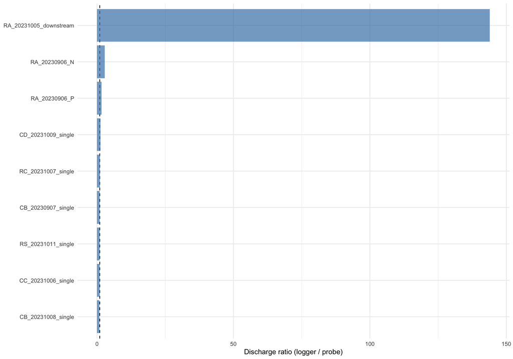

```r
events %>%
  filter(!is.na(discharge_ratio)) %>%
  ggplot(aes(reorder(event_id, discharge_ratio), discharge_ratio)) +
  geom_hline(yintercept = 1, linetype = "dashed") +
  geom_col(fill = "steelblue", alpha = 0.7) +
  coord_flip() +
  labs(x = NULL, y = "Discharge ratio (logger / probe)") +
  theme_minimal(base_size = 10)
```